# 09 Data Visualization Basics

Author

Kaijie Liu

Published

March 16, 2026

# Data Visualization

Data visualization is the practice of using visual representations — such as graphs, plots, and interactive charts — to explore patterns and communicate insights in datasets. It is closely tied to data analysis, where code is used to uncover trends, relationships, and structure within data.

Datasets can range from tiny lists of numbers to large‑scale collections containing many types of information. Effective visualization isn’t just about making charts look nice; it makes the meaning of data clearer. A well-designed visual can reveal patterns, trends, and significance that might be easy to miss in raw data.

Python makes this work accessible. The Python ecosystem includes powerful visualization tools created by data scientists. Two major tools introduced in this chapter are:

- Matplotlib: A mathematical plotting library used for classic plots like line graphs and scatter plots.
- Plotly: A library for interactive, device‑friendly visualizations that automatically resize and support features like hover effects.

# Matplotlib

## Install Matplotlib

To use Matplotlib, we will need to install it using pip.

- If using Jupyter Notebook, the easiest and safest way is to type and run:

```
%pip install matplotlib
```

- If you’re using VS Code to write and run Python code, you typically install Python packages using the integrated terminal, not inside a code cell. In the VS Code terminal, run:

```
pip install matplotlib
```

## Import `pyplot`

After installation, we can import `pyplot` in your Python scripts using alias `plt`, so that we don’t need to type `pyplot` repeatedly.

```python
import matplotlib.pyplot as plt
```

## Understanding subplots(), Figures, and Axes

We start by creating a list called `squares` to hold the data we want to plot.

Next, we follow a common Matplotlib convention by calling the subplots() function. This function can create one or more plots inside a single figure. - fig represents the entire figure — the overall container that can hold one or many plots. - ax represents a single plot within that figure (also called an Axes object). We’ll usually work with ax when customizing or styling an individual plot.

After setting up the figure and axes, we call the plot() method on the ax object. This method attempts to plot the data in a meaningful way based on the inputs you provide.

Finally, the line plt.show() opens Matplotlib’s viewer and displays the finished plot.

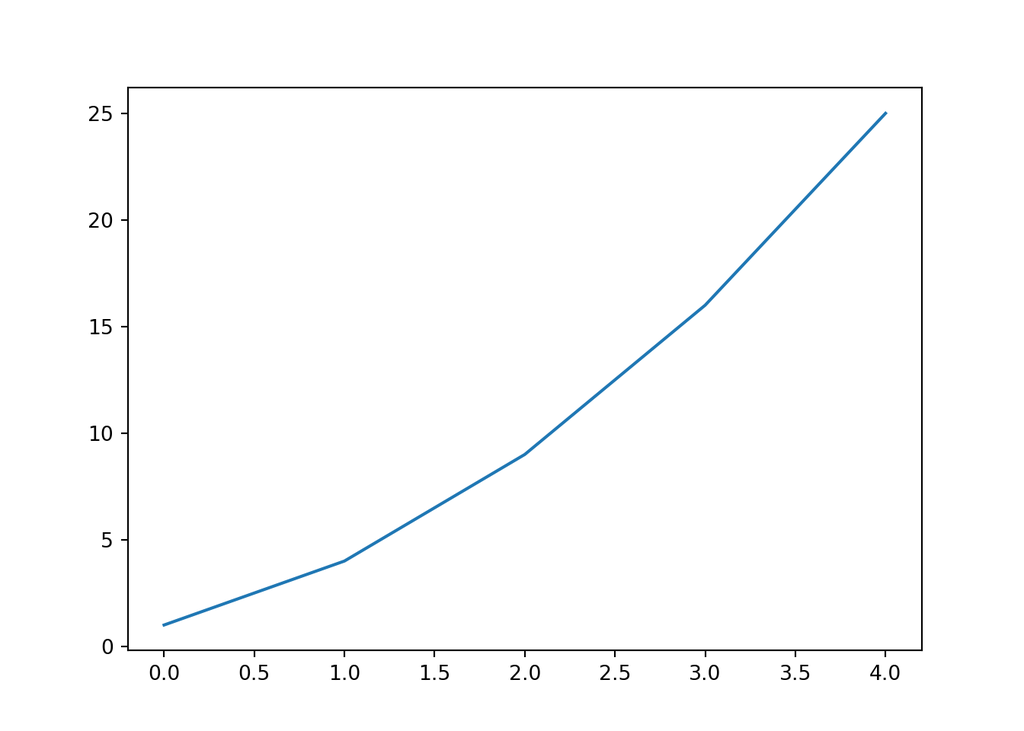

```python
squares = [1, 4, 9, 16, 25]

fig, ax = plt.subplots()
ax.plot(squares)

plt.show()
```

## Changing the Label Type and Line Thickness

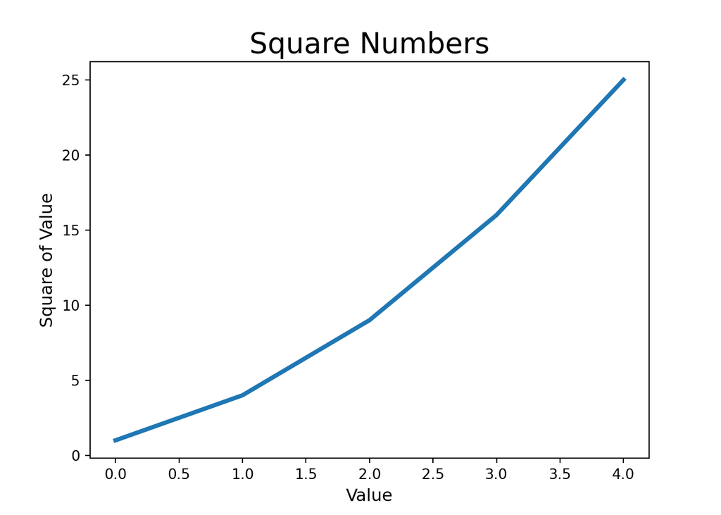

```python
squares = [1, 4, 9, 16, 25]

fig, ax = plt.subplots()

# Set linewidth
ax.plot(squares, linewidth=3)

# Set chart title and label axes.
ax.set_title("Square Numbers", fontsize=20)
ax.set_xlabel("Value", fontsize=12)
ax.set_ylabel("Square of Value", fontsize=12)

# Set size of tick labels.
ax.tick_params(labelsize=10)

plt.show()
```

- The `linewidth` parameter controls how thick the line appears when using the plot() method. Once a plot has been created, Matplotlib provides many methods for customizing its appearance before displaying it.
- The `set_title()` method sets the overall title for the chart.
- The `fontsize` parameter (used in several methods) controls the size of text on the chart, such as axis labels and titles.
- The `set_xlabel()` and `set_ylabel()` methods assign titles to the x‑ and y‑axes.
- The `tick_params()` method allows you to style the tick marks; in this example, it sets the font size of the tick labels on both axes.

## Correcting the Plot

When we give `plot()` a single sequence of numbers, it assumes the first data point corresponds to an x-value of 0, but the first point in `squares` corresponds to an x-value of 1. We can override this default behavior by giving `plot()` both the input and output values used to calculate the `squares`.

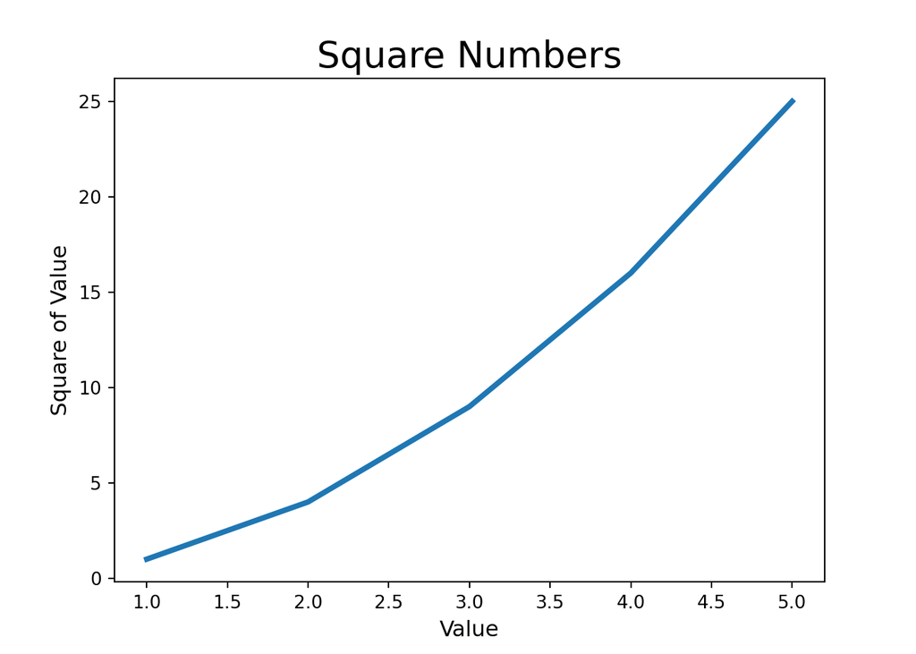

```python
input = [1, 2, 3, 4, 5]
output = [1, 4, 9, 16, 25]

fig, ax = plt.subplots()

# Set linewidth
ax.plot(input, output, linewidth=3)

# Set chart title and label axes.
ax.set_title("Square Numbers", fontsize=20)
ax.set_xlabel("Value", fontsize=12)
ax.set_ylabel("Square of Value", fontsize=12)

# Set size of tick labels.
ax.tick_params(labelsize=10)

plt.show()
```

## Using Built-in Styles

Matplotlib includes a collection of built‑in styles that we can apply to our plots. Each style comes with its own set of default settings - such as background colors, gridlines, line widths, fonts, and font sizes — which can instantly make your visualizations more appealing without requiring much manual customization.

To see all available styles, you can run the following in a Python interpreter:

```python
import matplotlib.pyplot as plt
plt.style.available
```

```
['Solarize_Light2', '_classic_test_patch', '_mpl-gallery', '_mpl-gallery-nogrid', 'bmh', 'classic', 'dark_background', 'fast', 'fivethirtyeight', 'ggplot', 'grayscale', 'petroff10', 'seaborn-v0_8', 'seaborn-v0_8-bright', 'seaborn-v0_8-colorblind', 'seaborn-v0_8-dark', 'seaborn-v0_8-dark-palette', 's…
```

To use any of these styles, add one line of code before calling subplots().

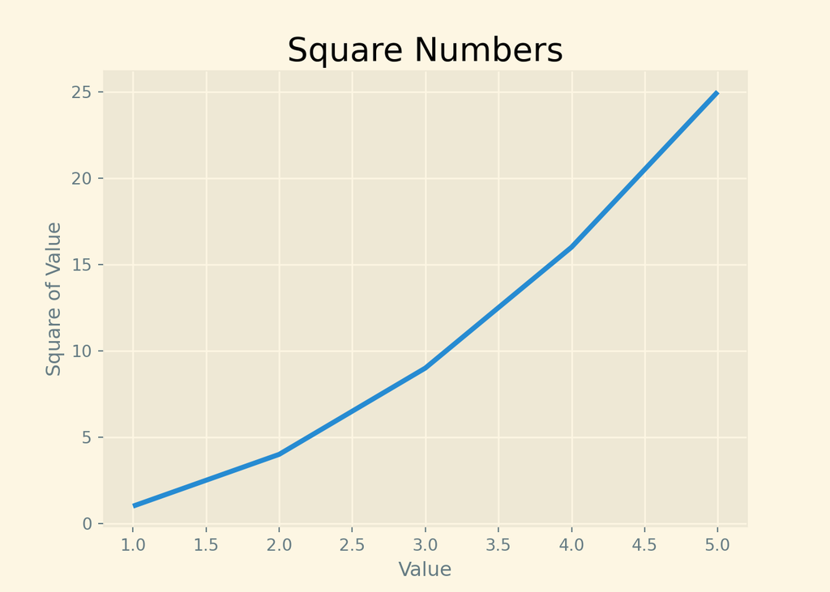

```python
input = [1, 2, 3, 4, 5]
output = [1, 4, 9, 16, 25]

plt.style.use('Solarize_Light2')  # see here
fig, ax = plt.subplots()

# Set linewidth
ax.plot(input, output, linewidth=3)

# Set chart title and label axes.
ax.set_title("Square Numbers", fontsize=20)
ax.set_xlabel("Value", fontsize=12)
ax.set_ylabel("Square of Value", fontsize=12)

# Set size of tick labels.
ax.tick_params(labelsize=10)

plt.show()
```

## Using `scatter()`

### Plotting and Styling Individual Points

Sometimes it’s useful to plot individual data points and style them based on certain characteristics. For example, we might use one color for smaller values and a different color for larger values. We can also plot a large dataset with one general style and then highlight a specific point by plotting it again with different styling options.

To plot a single point, simply pass one x-value and one y-value to the `scatter()` function.

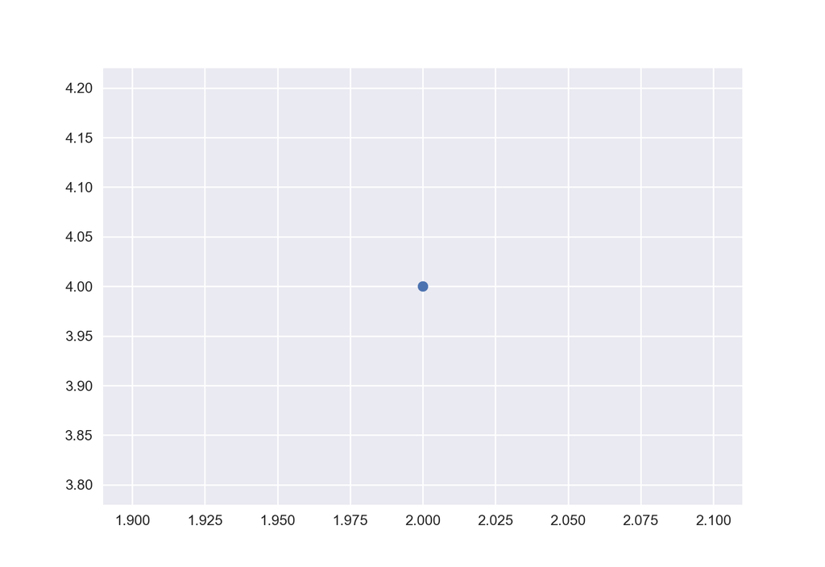

```python
import matplotlib.pyplot as plt

plt.style.use('seaborn-v0_8')

fig, ax = plt.subplots()

ax.scatter(2, 4)

plt.show()
```

To make it more interesting, we can use the `s` argument inside `scatter()` to set the size of the dots. we can also add a title, label the axes, and make the text the size we want.

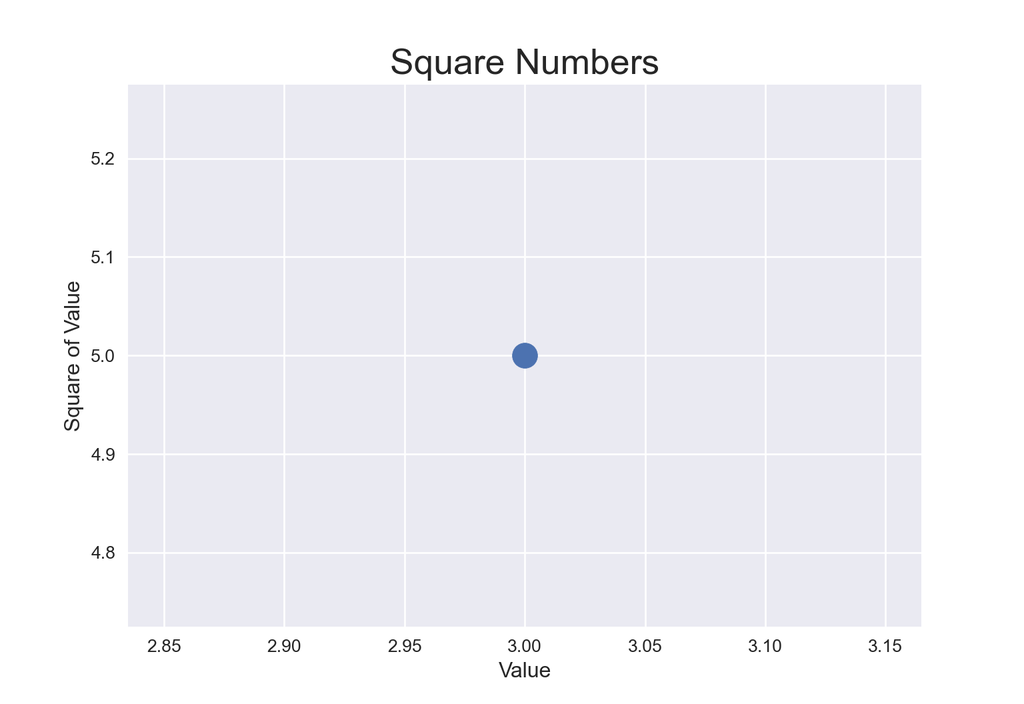

```python
import matplotlib.pyplot as plt

plt.style.use('seaborn-v0_8')
fig, ax = plt.subplots()
ax.scatter(3, 5, s = 200)

# Set chart title and label axes.
ax.set_title("Square Numbers", fontsize = 20)
ax.set_xlabel("Value", fontsize = 12)
ax.set_ylabel("Square of Value", fontsize = 12)

# Set size of tick labels.
ax.tick_params(labelsize=10)

plt.show()
```

### Plotting a Series of Points

To plot a series of points, we can pass scatter() separate lists of x- and y-values as follows.

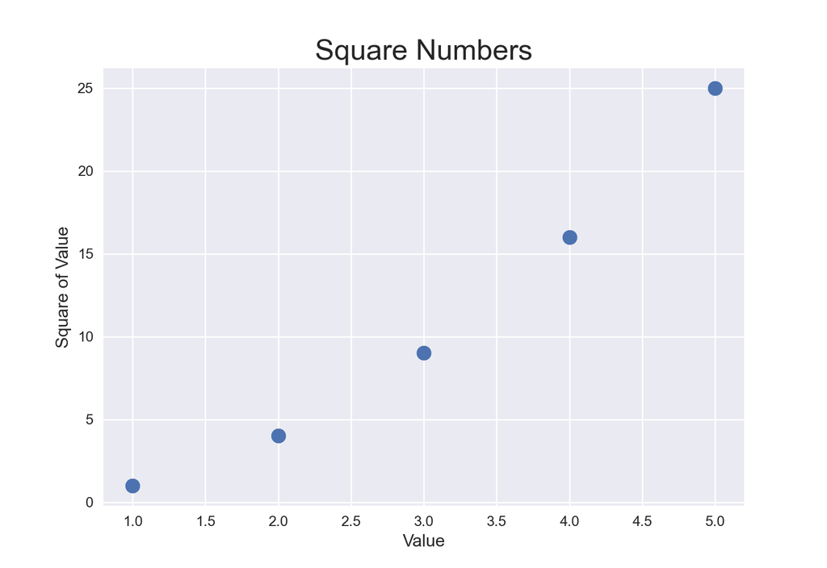

```python
import matplotlib.pyplot as plt

input = [1, 2, 3, 4, 5]
output = [1, 4, 9, 16, 25]

plt.style.use('seaborn-v0_8')
fig, ax = plt.subplots()
ax.scatter(input, output, s = 100)

# Set chart title and label axes.
ax.set_title("Square Numbers", fontsize = 20)
ax.set_xlabel("Value", fontsize = 12)
ax.set_ylabel("Square of Value", fontsize = 12)

# Set size of tick labels.
ax.tick_params(labelsize=10)

plt.show()
```